# Risk Factor Analysis

## Outcome Variable

**Outcome Variable:** stunted

## Predictor Variables

**Intervention Variable:** hfoodsec

**Adjustment Set:**

unadjusted

## Stratifying Variables

The analysis was stratified on these variable(s):

- agecat
- studyid
- country

## Data Summary

| agecat | studyid | country | hfoodsec | stunted | n_cell | n |
| --- | --- | --- | --- | --- | --- | --- |
| Birth | ki0047075b-MAL-ED | BANGLADESH | Food Secure | 0 | 133 | 188 |
| Birth | ki0047075b-MAL-ED | BANGLADESH | Food Secure | 1 | 24 | 188 |
| Birth | ki0047075b-MAL-ED | BANGLADESH | Mildly Food Insecure | 0 | 3 | 188 |
| Birth | ki0047075b-MAL-ED | BANGLADESH | Mildly Food Insecure | 1 | 1 | 188 |
| Birth | ki0047075b-MAL-ED | BANGLADESH | Moderately Food Insecure | 0 | 19 | 188 |
| Birth | ki0047075b-MAL-ED | BANGLADESH | Moderately Food Insecure | 1 | 3 | 188 |
| Birth | ki0047075b-MAL-ED | BANGLADESH | Severely Food Insecure | 0 | 4 | 188 |
| Birth | ki0047075b-MAL-ED | BANGLADESH | Severely Food Insecure | 1 | 1 | 188 |
| 6 months | ki0047075b-MAL-ED | BANGLADESH | Food Secure | 0 | 128 | 193 |
| 6 months | ki0047075b-MAL-ED | BANGLADESH | Food Secure | 1 | 32 | 193 |
| 6 months | ki0047075b-MAL-ED | BANGLADESH | Mildly Food Insecure | 0 | 2 | 193 |
| 6 months | ki0047075b-MAL-ED | BANGLADESH | Mildly Food Insecure | 1 | 2 | 193 |
| 6 months | ki0047075b-MAL-ED | BANGLADESH | Moderately Food Insecure | 0 | 21 | 193 |
| 6 months | ki0047075b-MAL-ED | BANGLADESH | Moderately Food Insecure | 1 | 2 | 193 |
| 6 months | ki0047075b-MAL-ED | BANGLADESH | Severely Food Insecure | 0 | 4 | 193 |
| 6 months | ki0047075b-MAL-ED | BANGLADESH | Severely Food Insecure | 1 | 2 | 193 |
| 24 months | ki0047075b-MAL-ED | BANGLADESH | Food Secure | 0 | 90 | 194 |
| 24 months | ki0047075b-MAL-ED | BANGLADESH | Food Secure | 1 | 71 | 194 |
| 24 months | ki0047075b-MAL-ED | BANGLADESH | Mildly Food Insecure | 0 | 1 | 194 |
| 24 months | ki0047075b-MAL-ED | BANGLADESH | Mildly Food Insecure | 1 | 3 | 194 |
| 24 months | ki0047075b-MAL-ED | BANGLADESH | Moderately Food Insecure | 0 | 10 | 194 |
| 24 months | ki0047075b-MAL-ED | BANGLADESH | Moderately Food Insecure | 1 | 13 | 194 |
| 24 months | ki0047075b-MAL-ED | BANGLADESH | Severely Food Insecure | 0 | 2 | 194 |
| 24 months | ki0047075b-MAL-ED | BANGLADESH | Severely Food Insecure | 1 | 4 | 194 |
| Birth | ki0047075b-MAL-ED | BRAZIL | Mildly Food Insecure | 0 | 10 | 105 |
| Birth | ki0047075b-MAL-ED | BRAZIL | Mildly Food Insecure | 1 | 1 | 105 |
| Birth | ki0047075b-MAL-ED | BRAZIL | Moderately Food Insecure | 0 | 46 | 105 |
| Birth | ki0047075b-MAL-ED | BRAZIL | Moderately Food Insecure | 1 | 8 | 105 |
| Birth | ki0047075b-MAL-ED | BRAZIL | Severely Food Insecure | 0 | 38 | 105 |
| Birth | ki0047075b-MAL-ED | BRAZIL | Severely Food Insecure | 1 | 2 | 105 |

[output cut: 210 more lines]

The following strata were considered:

- agecat: 24 months, studyid: ki0047075b-MAL-ED, country: BANGLADESH
- agecat: 24 months, studyid: ki0047075b-MAL-ED, country: BRAZIL
- agecat: 24 months, studyid: ki0047075b-MAL-ED, country: INDIA
- agecat: 24 months, studyid: ki0047075b-MAL-ED, country: NEPAL
- agecat: 24 months, studyid: ki0047075b-MAL-ED, country: PERU
- agecat: 24 months, studyid: ki0047075b-MAL-ED, country: SOUTH AFRICA
- agecat: 24 months, studyid: ki1017093-NIH-Birth, country: BANGLADESH
- agecat: 24 months, studyid: ki1017093c-NIH-Crypto, country: BANGLADESH
- agecat: 24 months, studyid: ki1113344-GMS-Nepal, country: NEPAL
- agecat: 24 months, studyid: kiGH5241-JiVitA-3, country: BANGLADESH
- agecat: 24 months, studyid: kiGH5241-JiVitA-4, country: BANGLADESH
- agecat: 6 months, studyid: ki0047075b-MAL-ED, country: BANGLADESH
- agecat: 6 months, studyid: ki0047075b-MAL-ED, country: BRAZIL
- agecat: 6 months, studyid: ki0047075b-MAL-ED, country: INDIA
- agecat: 6 months, studyid: ki0047075b-MAL-ED, country: NEPAL
- agecat: 6 months, studyid: ki0047075b-MAL-ED, country: PERU
- agecat: 6 months, studyid: ki0047075b-MAL-ED, country: SOUTH AFRICA
- agecat: 6 months, studyid: ki1017093-NIH-Birth, country: BANGLADESH
- agecat: 6 months, studyid: ki1017093c-NIH-Crypto, country: BANGLADESH
- agecat: 6 months, studyid: ki1113344-GMS-Nepal, country: NEPAL
- agecat: 6 months, studyid: kiGH5241-JiVitA-3, country: BANGLADESH
- agecat: 6 months, studyid: kiGH5241-JiVitA-4, country: BANGLADESH
- agecat: Birth, studyid: ki0047075b-MAL-ED, country: BANGLADESH
- agecat: Birth, studyid: ki0047075b-MAL-ED, country: BRAZIL
- agecat: Birth, studyid: ki0047075b-MAL-ED, country: INDIA
- agecat: Birth, studyid: ki0047075b-MAL-ED, country: NEPAL
- agecat: Birth, studyid: ki0047075b-MAL-ED, country: PERU
- agecat: Birth, studyid: ki0047075b-MAL-ED, country: SOUTH AFRICA
- agecat: Birth, studyid: ki1017093-NIH-Birth, country: BANGLADESH
- agecat: Birth, studyid: ki1017093c-NIH-Crypto, country: BANGLADESH
- agecat: Birth, studyid: kiGH5241-JiVitA-3, country: BANGLADESH
- agecat: Birth, studyid: kiGH5241-JiVitA-4, country: BANGLADESH

### Dropped Strata

Some strata were dropped due to rare outcomes:

- agecat: Birth, studyid: ki0047075b-MAL-ED, country: BANGLADESH
- agecat: 6 months, studyid: ki0047075b-MAL-ED, country: BANGLADESH
- agecat: 24 months, studyid: ki0047075b-MAL-ED, country: BANGLADESH
- agecat: Birth, studyid: ki0047075b-MAL-ED, country: BRAZIL
- agecat: 6 months, studyid: ki0047075b-MAL-ED, country: BRAZIL
- agecat: 24 months, studyid: ki0047075b-MAL-ED, country: BRAZIL
- agecat: Birth, studyid: ki0047075b-MAL-ED, country: INDIA
- agecat: 6 months, studyid: ki0047075b-MAL-ED, country: INDIA
- agecat: 24 months, studyid: ki0047075b-MAL-ED, country: INDIA
- agecat: Birth, studyid: ki0047075b-MAL-ED, country: NEPAL
- agecat: 6 months, studyid: ki0047075b-MAL-ED, country: NEPAL
- agecat: 24 months, studyid: ki0047075b-MAL-ED, country: NEPAL
- agecat: Birth, studyid: ki0047075b-MAL-ED, country: PERU
- agecat: Birth, studyid: ki0047075b-MAL-ED, country: SOUTH AFRICA
- agecat: 6 months, studyid: ki0047075b-MAL-ED, country: SOUTH AFRICA
- agecat: 24 months, studyid: ki0047075b-MAL-ED, country: SOUTH AFRICA
- agecat: 6 months, studyid: ki1017093-NIH-Birth, country: BANGLADESH
- agecat: 24 months, studyid: ki1017093-NIH-Birth, country: BANGLADESH
- agecat: Birth, studyid: ki1017093-NIH-Birth, country: BANGLADESH
- agecat: Birth, studyid: ki1017093c-NIH-Crypto, country: BANGLADESH
- agecat: 6 months, studyid: ki1113344-GMS-Nepal, country: NEPAL

## Methods Detail

We’re interested in the causal parameters $E[Y_a]$ for all values of $a \in \mathcal{A}$. These parameters represent the mean outcome if, possibly contrary to fact, we intervened to set all units to have $A=a$. Under the randomization and positivity assumptions, these are identified by the statistical parameters $\psi_a=E_W[E_{Y|A,W}(Y|A=a,W)]$. In addition, we’re interested in the mean of $Y$, $E[Y]$ under no intervention (the observed mean). We will estimate these parameters by using SuperLearner to fit the relevant likelihood factors – $E_{Y|A,W}(Y|A=a,W)$ and $p(A=a|W)$, and then updating our likelihood fit using a joint TMLE.

For unadjusted analyses ($W=\{\}$), initial likelihoods were estimated using Lrnr_glm to estimate the simple $E(Y|A)$ and Lrnr_mean to estimate $p(A)$. For adjusted analyses, a small library containing Lrnr_glmnet, Lrnr_xgboost, and Lrnr_mean was used.

Having estimated these parameters, we will then use the delta method to estimate relative risks and attributable risks relative to a prespecified baseline level of $A$.

# Results Detail

## Results Plots

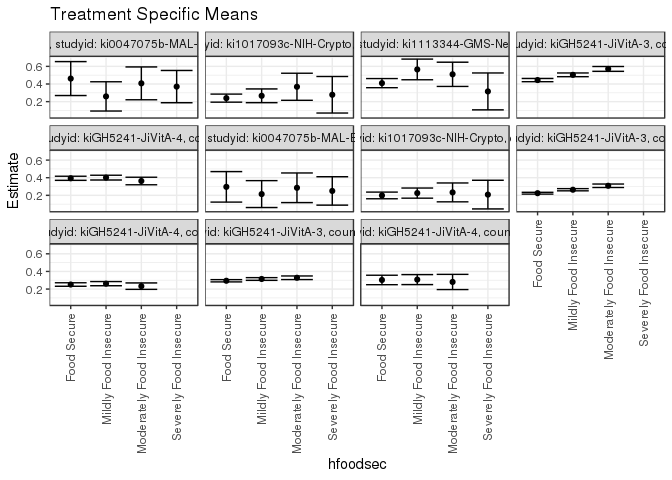

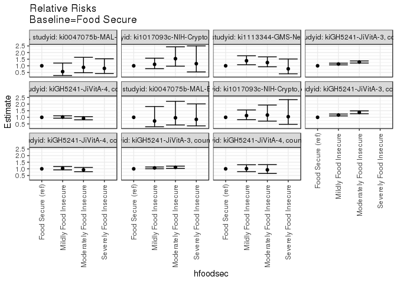

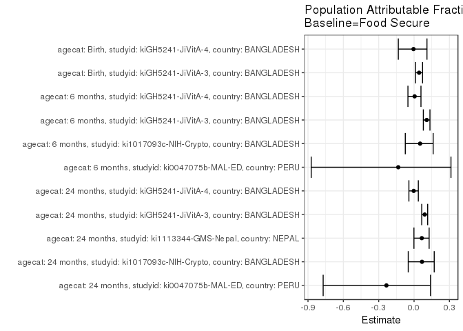

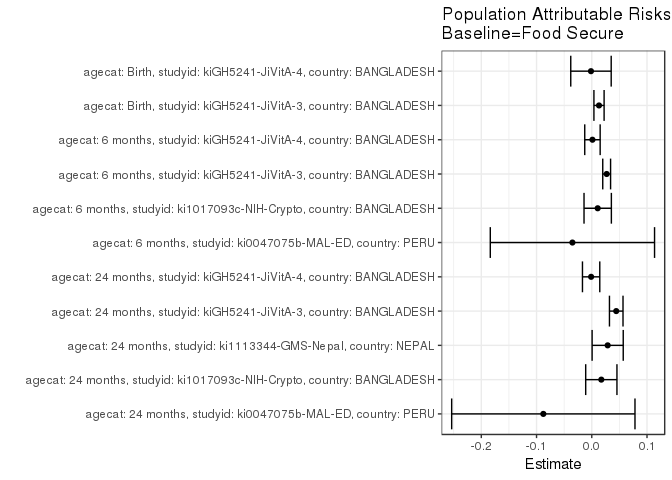

## Results Table

### Parameter: TSM

| agecat | studyid | country | intervention_level | baseline_level | estimate | ci_lower | ci_upper |
| --- | --- | --- | --- | --- | --- | --- | --- |
| Birth | kiGH5241-JiVitA-3 | BANGLADESH | Food Secure | NA | 0.2941471 | 0.2814357 | 0.3068585 |
| Birth | kiGH5241-JiVitA-3 | BANGLADESH | Mildly Food Insecure | NA | 0.3144175 | 0.2991416 | 0.3296935 |
| Birth | kiGH5241-JiVitA-3 | BANGLADESH | Moderately Food Insecure | NA | 0.3282006 | 0.3079382 | 0.3484630 |
| Birth | kiGH5241-JiVitA-4 | BANGLADESH | Food Secure | NA | 0.3030303 | 0.2493889 | 0.3566717 |
| Birth | kiGH5241-JiVitA-4 | BANGLADESH | Mildly Food Insecure | NA | 0.3074434 | 0.2507179 | 0.3641688 |
| Birth | kiGH5241-JiVitA-4 | BANGLADESH | Moderately Food Insecure | NA | 0.2807018 | 0.1944590 | 0.3669445 |
| 6 months | ki0047075b-MAL-ED | PERU | Food Secure | NA | 0.2962963 | 0.1232791 | 0.4693135 |
| 6 months | ki0047075b-MAL-ED | PERU | Mildly Food Insecure | NA | 0.2142857 | 0.0616124 | 0.3669590 |
| 6 months | ki0047075b-MAL-ED | PERU | Moderately Food Insecure | NA | 0.2857143 | 0.1176265 | 0.4538021 |
| 6 months | ki0047075b-MAL-ED | PERU | Severely Food Insecure | NA | 0.2500000 | 0.0888854 | 0.4111146 |
| 6 months | ki1017093c-NIH-Crypto | BANGLADESH | Food Secure | NA | 0.1990632 | 0.1611638 | 0.2369627 |
| 6 months | ki1017093c-NIH-Crypto | BANGLADESH | Mildly Food Insecure | NA | 0.2254902 | 0.1681031 | 0.2828773 |
| 6 months | ki1017093c-NIH-Crypto | BANGLADESH | Moderately Food Insecure | NA | 0.2333333 | 0.1262386 | 0.3404281 |
| 6 months | ki1017093c-NIH-Crypto | BANGLADESH | Severely Food Insecure | NA | 0.2083333 | 0.0457422 | 0.3709245 |
| 6 months | kiGH5241-JiVitA-3 | BANGLADESH | Food Secure | NA | 0.2244801 | 0.2142903 | 0.2346699 |
| 6 months | kiGH5241-JiVitA-3 | BANGLADESH | Mildly Food Insecure | NA | 0.2636558 | 0.2510168 | 0.2762948 |
| 6 months | kiGH5241-JiVitA-3 | BANGLADESH | Moderately Food Insecure | NA | 0.3085797 | 0.2887924 | 0.3283670 |
| 6 months | kiGH5241-JiVitA-4 | BANGLADESH | Food Secure | NA | 0.2514333 | 0.2316127 | 0.2712538 |
| 6 months | kiGH5241-JiVitA-4 | BANGLADESH | Mildly Food Insecure | NA | 0.2614228 | 0.2376757 | 0.2851698 |
| 6 months | kiGH5241-JiVitA-4 | BANGLADESH | Moderately Food Insecure | NA | 0.2331190 | 0.1966330 | 0.2696049 |
| 24 months | ki0047075b-MAL-ED | PERU | Food Secure | NA | 0.4615385 | 0.2690159 | 0.6540610 |
| 24 months | ki0047075b-MAL-ED | PERU | Mildly Food Insecure | NA | 0.2592593 | 0.0931838 | 0.4253347 |
| 24 months | ki0047075b-MAL-ED | PERU | Moderately Food Insecure | NA | 0.4074074 | 0.2211997 | 0.5936151 |
| 24 months | ki0047075b-MAL-ED | PERU | Severely Food Insecure | NA | 0.3703704 | 0.1873641 | 0.5533766 |
| 24 months | ki1017093c-NIH-Crypto | BANGLADESH | Food Secure | NA | 0.2395210 | 0.1937054 | 0.2853365 |
| 24 months | ki1017093c-NIH-Crypto | BANGLADESH | Mildly Food Insecure | NA | 0.2661290 | 0.1882687 | 0.3439893 |
| 24 months | ki1017093c-NIH-Crypto | BANGLADESH | Moderately Food Insecure | NA | 0.3684211 | 0.2149010 | 0.5219411 |
| 24 months | ki1017093c-NIH-Crypto | BANGLADESH | Severely Food Insecure | NA | 0.2777778 | 0.0706593 | 0.4848963 |
| 24 months | ki1113344-GMS-Nepal | NEPAL | Food Secure | NA | 0.4097421 | 0.3580937 | 0.4613905 |
| 24 months | ki1113344-GMS-Nepal | NEPAL | Mildly Food Insecure | NA | 0.5652174 | 0.4481293 | 0.6823055 |
| 24 months | ki1113344-GMS-Nepal | NEPAL | Moderately Food Insecure | NA | 0.5098039 | 0.3724646 | 0.6471433 |
| 24 months | ki1113344-GMS-Nepal | NEPAL | Severely Food Insecure | NA | 0.3157895 | 0.1065660 | 0.5250130 |
| 24 months | kiGH5241-JiVitA-3 | BANGLADESH | Food Secure | NA | 0.4443871 | 0.4261256 | 0.4626486 |
| 24 months | kiGH5241-JiVitA-3 | BANGLADESH | Mildly Food Insecure | NA | 0.5038030 | 0.4826672 | 0.5249388 |
| 24 months | kiGH5241-JiVitA-3 | BANGLADESH | Moderately Food Insecure | NA | 0.5709759 | 0.5435392 | 0.5984126 |
| 24 months | kiGH5241-JiVitA-4 | BANGLADESH | Food Secure | NA | 0.3934973 | 0.3701819 | 0.4168127 |
| 24 months | kiGH5241-JiVitA-4 | BANGLADESH | Mildly Food Insecure | NA | 0.4011730 | 0.3739779 | 0.4283682 |
| 24 months | kiGH5241-JiVitA-4 | BANGLADESH | Moderately Food Insecure | NA | 0.3628900 | 0.3201459 | 0.4056341 |

### Parameter: E(Y)

| agecat | studyid | country | intervention_level | baseline_level | estimate | ci_lower | ci_upper |
| --- | --- | --- | --- | --- | --- | --- | --- |
| Birth | kiGH5241-JiVitA-3 | BANGLADESH | NA | NA | 0.3072590 | 0.2982359 | 0.3162822 |
| Birth | kiGH5241-JiVitA-4 | BANGLADESH | NA | NA | 0.3015873 | 0.2659035 | 0.3372711 |
| 6 months | ki0047075b-MAL-ED | PERU | NA | NA | 0.2612613 | 0.1791629 | 0.3433597 |
| 6 months | ki1017093c-NIH-Crypto | BANGLADESH | NA | NA | 0.2097902 | 0.1799252 | 0.2396552 |
| 6 months | kiGH5241-JiVitA-3 | BANGLADESH | NA | NA | 0.2514442 | 0.2432971 | 0.2595914 |
| 6 months | kiGH5241-JiVitA-4 | BANGLADESH | NA | NA | 0.2526601 | 0.2384064 | 0.2669139 |
| 24 months | ki0047075b-MAL-ED | PERU | NA | NA | 0.3738318 | 0.2817277 | 0.4659358 |
| 24 months | ki1017093c-NIH-Crypto | BANGLADESH | NA | NA | 0.2568093 | 0.2190047 | 0.2946140 |
| 24 months | ki1113344-GMS-Nepal | NEPAL | NA | NA | 0.4385246 | 0.3944543 | 0.4825949 |
| 24 months | kiGH5241-JiVitA-3 | BANGLADESH | NA | NA | 0.4886779 | 0.4752340 | 0.5021218 |
| 24 months | kiGH5241-JiVitA-4 | BANGLADESH | NA | NA | 0.3923191 | 0.3753084 | 0.4093298 |

### Parameter: RR

| agecat | studyid | country | intervention_level | baseline_level | estimate | ci_lower | ci_upper |
| --- | --- | --- | --- | --- | --- | --- | --- |
| Birth | kiGH5241-JiVitA-3 | BANGLADESH | Food Secure | Food Secure | 1.0000000 | 1.0000000 | 1.000000 |
| Birth | kiGH5241-JiVitA-3 | BANGLADESH | Mildly Food Insecure | Food Secure | 1.0689127 | 1.0032397 | 1.138885 |
| Birth | kiGH5241-JiVitA-3 | BANGLADESH | Moderately Food Insecure | Food Secure | 1.1157705 | 1.0339887 | 1.204021 |
| Birth | kiGH5241-JiVitA-4 | BANGLADESH | Food Secure | Food Secure | 1.0000000 | 1.0000000 | 1.000000 |
| Birth | kiGH5241-JiVitA-4 | BANGLADESH | Mildly Food Insecure | Food Secure | 1.0145631 | 0.7861440 | 1.309351 |
| Birth | kiGH5241-JiVitA-4 | BANGLADESH | Moderately Food Insecure | Food Secure | 0.9263158 | 0.6510670 | 1.317930 |
| 6 months | ki0047075b-MAL-ED | PERU | Food Secure | Food Secure | 1.0000000 | 1.0000000 | 1.000000 |
| 6 months | ki0047075b-MAL-ED | PERU | Mildly Food Insecure | Food Secure | 0.7232143 | 0.2878706 | 1.816924 |
| 6 months | ki0047075b-MAL-ED | PERU | Moderately Food Insecure | Food Secure | 0.9642857 | 0.4209368 | 2.208994 |
| 6 months | ki0047075b-MAL-ED | PERU | Severely Food Insecure | Food Secure | 0.8437500 | 0.3536114 | 2.013267 |
| 6 months | ki1017093c-NIH-Crypto | BANGLADESH | Food Secure | Food Secure | 1.0000000 | 1.0000000 | 1.000000 |
| 6 months | ki1017093c-NIH-Crypto | BANGLADESH | Mildly Food Insecure | Food Secure | 1.1327566 | 0.8243345 | 1.556574 |
| 6 months | ki1017093c-NIH-Crypto | BANGLADESH | Moderately Food Insecure | Food Secure | 1.1721569 | 0.7131575 | 1.926575 |
| 6 months | ki1017093c-NIH-Crypto | BANGLADESH | Severely Food Insecure | Food Secure | 1.0465686 | 0.4686927 | 2.336938 |
| 6 months | kiGH5241-JiVitA-3 | BANGLADESH | Food Secure | Food Secure | 1.0000000 | 1.0000000 | 1.000000 |
| 6 months | kiGH5241-JiVitA-3 | BANGLADESH | Mildly Food Insecure | Food Secure | 1.1745177 | 1.1056736 | 1.247648 |
| 6 months | kiGH5241-JiVitA-3 | BANGLADESH | Moderately Food Insecure | Food Secure | 1.3746416 | 1.2714008 | 1.486266 |
| 6 months | kiGH5241-JiVitA-4 | BANGLADESH | Food Secure | Food Secure | 1.0000000 | 1.0000000 | 1.000000 |
| 6 months | kiGH5241-JiVitA-4 | BANGLADESH | Mildly Food Insecure | Food Secure | 1.0397304 | 0.9212718 | 1.173421 |
| 6 months | kiGH5241-JiVitA-4 | BANGLADESH | Moderately Food Insecure | Food Secure | 0.9271605 | 0.7793360 | 1.103024 |
| 24 months | ki0047075b-MAL-ED | PERU | Food Secure | Food Secure | 1.0000000 | 1.0000000 | 1.000000 |
| 24 months | ki0047075b-MAL-ED | PERU | Mildly Food Insecure | Food Secure | 0.5617284 | 0.2615430 | 1.206451 |
| 24 months | ki0047075b-MAL-ED | PERU | Moderately Food Insecure | Food Secure | 0.8827160 | 0.4754279 | 1.638918 |
| 24 months | ki0047075b-MAL-ED | PERU | Severely Food Insecure | Food Secure | 0.8024691 | 0.4203332 | 1.532015 |
| 24 months | ki1017093c-NIH-Crypto | BANGLADESH | Food Secure | Food Secure | 1.0000000 | 1.0000000 | 1.000000 |
| 24 months | ki1017093c-NIH-Crypto | BANGLADESH | Mildly Food Insecure | Food Secure | 1.1110887 | 0.7833260 | 1.575995 |
| 24 months | ki1017093c-NIH-Crypto | BANGLADESH | Moderately Food Insecure | Food Secure | 1.5381579 | 0.9724689 | 2.432911 |
| 24 months | ki1017093c-NIH-Crypto | BANGLADESH | Severely Food Insecure | Food Secure | 1.1597222 | 0.5370896 | 2.504155 |
| 24 months | ki1113344-GMS-Nepal | NEPAL | Food Secure | Food Secure | 1.0000000 | 1.0000000 | 1.000000 |
| 24 months | ki1113344-GMS-Nepal | NEPAL | Mildly Food Insecure | Food Secure | 1.3794466 | 1.0824103 | 1.757996 |
| 24 months | ki1113344-GMS-Nepal | NEPAL | Moderately Food Insecure | Food Secure | 1.2442068 | 0.9241050 | 1.675189 |
| 24 months | ki1113344-GMS-Nepal | NEPAL | Severely Food Insecure | Food Secure | 0.7707030 | 0.3926340 | 1.512816 |
| 24 months | kiGH5241-JiVitA-3 | BANGLADESH | Food Secure | Food Secure | 1.0000000 | 1.0000000 | 1.000000 |
| 24 months | kiGH5241-JiVitA-3 | BANGLADESH | Mildly Food Insecure | Food Secure | 1.1337030 | 1.0734850 | 1.197299 |
| 24 months | kiGH5241-JiVitA-3 | BANGLADESH | Moderately Food Insecure | Food Secure | 1.2848616 | 1.2088434 | 1.365660 |
| 24 months | kiGH5241-JiVitA-4 | BANGLADESH | Food Secure | Food Secure | 1.0000000 | 1.0000000 | 1.000000 |
| 24 months | kiGH5241-JiVitA-4 | BANGLADESH | Mildly Food Insecure | Food Secure | 1.0195064 | 0.9340605 | 1.112769 |
| 24 months | kiGH5241-JiVitA-4 | BANGLADESH | Moderately Food Insecure | Food Secure | 0.9222172 | 0.8097941 | 1.050248 |

### Parameter: PAR

| agecat | studyid | country | intervention_level | baseline_level | estimate | ci_lower | ci_upper |
| --- | --- | --- | --- | --- | --- | --- | --- |
| Birth | kiGH5241-JiVitA-3 | BANGLADESH | Food Secure | NA | 0.0131120 | 0.0038942 | 0.0223297 |
| Birth | kiGH5241-JiVitA-4 | BANGLADESH | Food Secure | NA | -0.0014430 | -0.0380552 | 0.0351692 |
| 6 months | ki0047075b-MAL-ED | PERU | Food Secure | NA | -0.0350350 | -0.1837366 | 0.1136665 |
| 6 months | ki1017093c-NIH-Crypto | BANGLADESH | Food Secure | NA | 0.0107270 | -0.0140254 | 0.0354794 |
| 6 months | kiGH5241-JiVitA-3 | BANGLADESH | Food Secure | NA | 0.0269641 | 0.0198662 | 0.0340621 |
| 6 months | kiGH5241-JiVitA-4 | BANGLADESH | Food Secure | NA | 0.0012269 | -0.0127304 | 0.0151842 |
| 24 months | ki0047075b-MAL-ED | PERU | Food Secure | NA | -0.0877067 | -0.2536441 | 0.0782307 |
| 24 months | ki1017093c-NIH-Crypto | BANGLADESH | Food Secure | NA | 0.0172884 | -0.0110010 | 0.0455777 |
| 24 months | ki1113344-GMS-Nepal | NEPAL | Food Secure | NA | 0.0287825 | 0.0005997 | 0.0569652 |
| 24 months | kiGH5241-JiVitA-3 | BANGLADESH | Food Secure | NA | 0.0442908 | 0.0320204 | 0.0565611 |
| 24 months | kiGH5241-JiVitA-4 | BANGLADESH | Food Secure | NA | -0.0011782 | -0.0168492 | 0.0144929 |

### Parameter: PAF

| agecat | studyid | country | intervention_level | baseline_level | estimate | ci_lower | ci_upper |
| --- | --- | --- | --- | --- | --- | --- | --- |
| Birth | kiGH5241-JiVitA-3 | BANGLADESH | Food Secure | NA | 0.0426739 | 0.0122092 | 0.0721991 |
| Birth | kiGH5241-JiVitA-4 | BANGLADESH | Food Secure | NA | -0.0047847 | -0.1337581 | 0.1095171 |
| 6 months | ki0047075b-MAL-ED | PERU | Food Secure | NA | -0.1340996 | -0.8728000 | 0.3132305 |
| 6 months | ki1017093c-NIH-Crypto | BANGLADESH | Food Secure | NA | 0.0511319 | -0.0743775 | 0.1619793 |
| 6 months | kiGH5241-JiVitA-3 | BANGLADESH | Food Secure | NA | 0.1072370 | 0.0787378 | 0.1348546 |
| 6 months | kiGH5241-JiVitA-4 | BANGLADESH | Food Secure | NA | 0.0048558 | -0.0519446 | 0.0585893 |
| 24 months | ki0047075b-MAL-ED | PERU | Food Secure | NA | -0.2346154 | -0.7713345 | 0.1394764 |
| 24 months | ki1017093c-NIH-Crypto | BANGLADESH | Food Secure | NA | 0.0673199 | -0.0494277 | 0.1710795 |
| 24 months | ki1113344-GMS-Nepal | NEPAL | Food Secure | NA | 0.0656348 | -0.0010605 | 0.1278866 |
| 24 months | kiGH5241-JiVitA-3 | BANGLADESH | Food Secure | NA | 0.0906339 | 0.0650309 | 0.1155358 |
| 24 months | kiGH5241-JiVitA-4 | BANGLADESH | Food Secure | NA | -0.0030031 | -0.0437518 | 0.0361548 |